# NNA GA Prototype Review

Erich Seamon

September 2019

## Genetic Algorithm review

The following set of steps provide a general review of a genetic algorithm approach, using simulated data from a optimization test function. Genetic algorithms (GA) fall within the the grouping metaheuristic procedures, modeled after the process of natural selection. A large set of research (Holland, 1960; Goldberg, 1989; Mitchell, 1996; Banzhaf et al., 1998; Bies et al., 2006) have explored the use and value of genetic algorithmic modeling, primarly for optimization and search efforts that apply evolutionary features such as selection, crossover, and mutation.

GA theory takes a population of outcomes/solutions to a problem set, and attempts to model (“evolve”) said solutions in a manner that allows for zeroing in on the most optimized result. Each solution may be multi-dimensional (i.e. an N-numbered array) which is altered (“mutated”) in an iterative fashion. After each iteration (“generation”), the fitness of each outcome is evaluated - against a known/predetermined objective function. As such, these two components: 1) the outcome/solution domain, as well as 2) the function for evaluating generational fitness - are essential in an appropriate genetic algorithmic model. For our proposed GA applied effort, the solution domain would be a multi-dimensional representation of input data that varied across space, and potentially time. Our fitness function would be represented as an known overall spatiotemporal pattern (ie. ocean acidification).

In order to prototype a GA approach, we have constructed a modeling process which uses an known objective test function, to evaluate a typical GA iterative process. For our purposes, we are using the Rastrigin optimization function. The Rastrigin function is non-convex, ,non-linear, and multimodal, and is frequently used to test optimization algorithms, given its large search space and numerous local minima. The Rastrigin function can be defined as:

$$\begin{aligned}
f(x) = \sum_{i=1}^{n} [x_i^{2} - A cos(2 \pi x_i)]
\\
where \ A = 10 \ and \ x_i \ \epsilon \ [-5.12, 5.12]
\\
with \ a \ global \ minimum \ at \ x=0
\\
where \ f(x) = 0
\end{aligned}$$

## Rastrigin Function Plotted in 3d

Here we construct the function and plot in 3 dimensions. Please note the numerous local minima that surround the global minima in the center of the function. The purpose of using a GA is to discern these minima. While this example attempts to find the global minima - the process of diserning between local and global is an important facet to identify spatial micropatterns within a t=1 function. A t+n/time series prepresentation will likelyr require a combinatory approach of GA runs which are associated (e.g. island-model distributed GA methods).

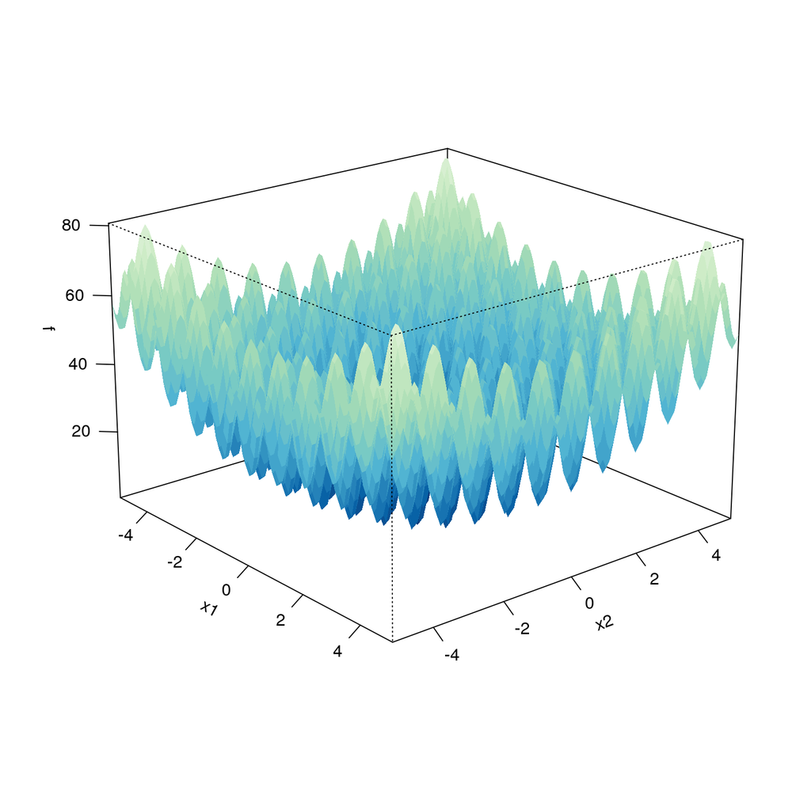

```r
usePackage("rgl")
usePackage("GA")
#usePackage("animation")
#usePackage("ffmpeg")

#--use of Rastrigin objective function to test optimization

Rastrigin <- function(x1, x2)
{
  20 + x1^2 + x2^2 - 10*(cos(2*pi*x1) + cos(2*pi*x2))
}


x1 <- x2 <- seq(-5.12, 5.12, by = 0.1)
f <- outer(x1, x2, Rastrigin)
persp3D(x1, x2, f, theta = 50, phi = 20, col.palette = bl2gr.colors)
```

## Rastrigin Function Plotted in 2d

Plotted in 2 dimensions provides a simpler depiction of the global and local minima.

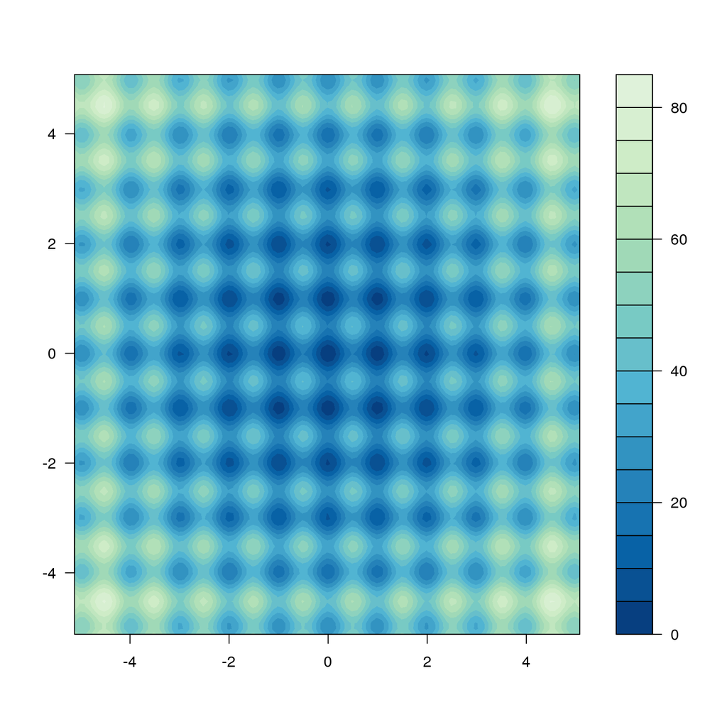

```r
filled.contour(x1, x2, f, color.palette = bl2gr.colors)
```

## Construction of a monitoring function and running of GA over 100 iterations

Here we run our GA across 100 iterations, using a sample of 50 observations/individuals. The output graph plots the iteration number - a fitness function prediction vs. the suggested solution.

In addition, we construct a monitoring function which generates an animation of our GA run or each of the iterations. The monitoring function constructs a .pdf of each 2-d representation of the GA. When animated, we see how the algorithm attempts to converge on the global minima across a test number of 100 iterations.

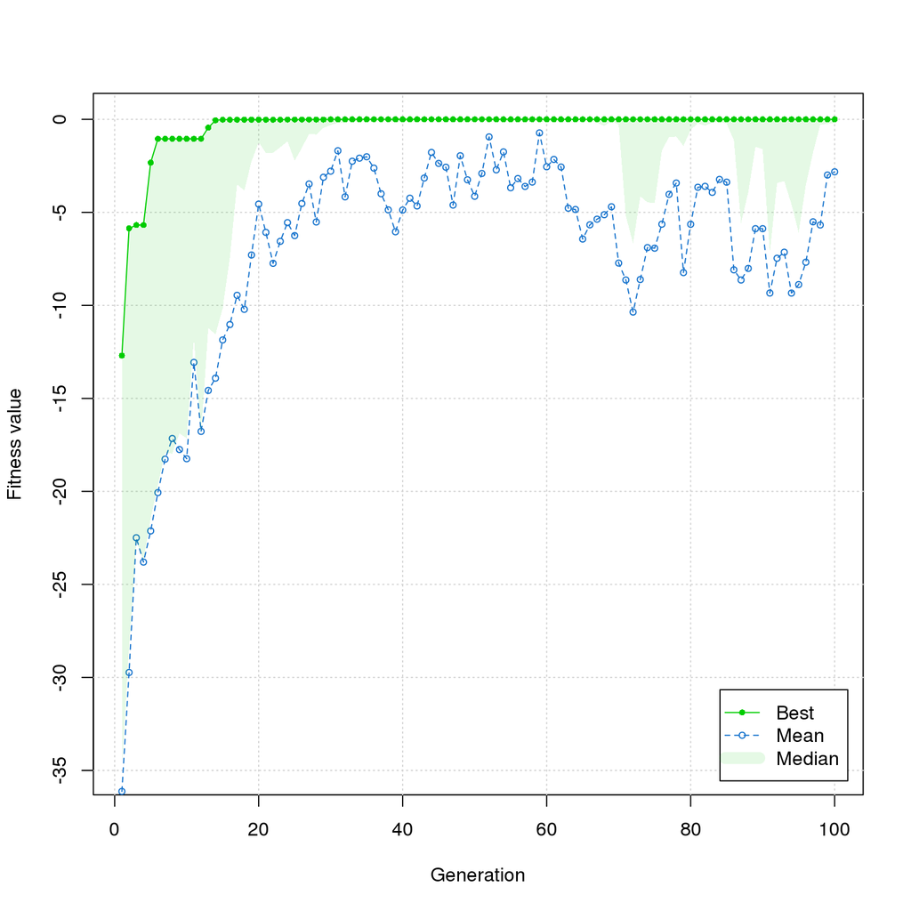

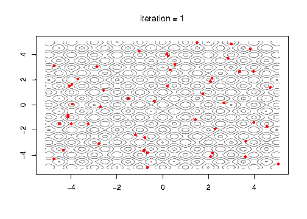

```r
dir.create("/tmp/seamon/GA_Rastrigin")
library(stringr)
monitor <- function(obj)
{
  setwd("/tmp/seamon/GA_Rastrigin")
  i <- str_pad(obj@iter, 6, pad = "0")
  pdf(paste(i, ".pdf", sep=""),width=7,height=5)
  contour(x1, x2, f, drawlabels = FALSE, col = grey(0.5))
  title(paste("iteration =", obj@iter), font.main = 1)
  points(obj@population, pch = 20, col = 2)
  Sys.sleep(0.2)
  dev.off()
}


suggestedSol <- matrix(c(0.2,1.5,-1.5,0.5), nrow = 2, ncol = 2, byrow = TRUE)

#dir.create("/tmp/seamon")

GA <- ga(type = "real-valued",
         fitness =  function(x) -Rastrigin(x[1], x[2]),
         lower = c(-5.12, -5.12), upper = c(5.12, 5.12),
         suggestions = suggestedSol,
         popSize = 50, maxiter = 100, run = 100, monitor = monitor)

#readLines("/tmp/seamon/GA_Rastrigin/rename.sh")
#system("rm -r /tmp/seamon/GA_Rastrigin/*Rastrigin.pdf")
system("convert -delay 30 -loop 0 -dispose background *.pdf animated.gif")
plot(GA)
```

## GA summary notation

The summary output of our GA run provides the number of observation, iterations, and set elitism, crossover, and mutation parameters. These parameters can be altered and evaluted as part of our iterative model approach.

```r
summary(GA)
```

```
## ── Genetic Algorithm ───────────────────
##
## GA settings:
## Type                  =  real-valued
## Population size       =  50
## Number of generations =  100
## Elitism               =  2
## Crossover probability =  0.8
## Mutation probability  =  0.1
## Search domain =
##          x1    x2
## lower -5.12 -5.12
## upper  5.12  5.12
## Suggestions =
##     x1  x2
## 1  0.2 1.5
## 2 -1.5 0.5
##
## GA results:
## Iterations             = 100
## Fitness function value = -2.42038e-06
## Solution =
##                x1           x2
## [1,] 6.607013e-05 8.851395e-05
```

## Summary and Takeaways

This basic example provides a very simple examination of a GA and its evaluation using a known optimization function. Some key issues to address in a process with actual climatic/biological/geophysical data:

1. Construction/determination of an appropriate fitness function. A key aspect will be to effectively zero in on what an initial fitness function will be. In order for the GA to attempt to optimize solution inputs, we need to have a representative fitness function, either thru historical outputs, stakeholder input, or another previously-evaluated output that is an acceptable view of the problem set.
2. Inputs. Scientifically validated inputs with apriori knowledge of the suggested solution.
3. Issues of time. While this example picks a single point in time - our efforts will involve time series data. An adaptive modeling effort will need to be established is a distributed and/or parallel manner (e.g. associated GA runs).
4. Comparisons of outcomes between regional landscapes.
5. GA performance. Because a given problem depends on its control parameters, choosing the wrong set of parameters could lead to unacceptable results.